# Senior BI Analyst Report: Daily Campaign Budget Analysis

## (STEP-12): Monthly Campaign Cycle Analysis

**Monthly Starting and ending Campaigns**

```python
"""
    Analysis of campaign life cycles
"""
print("=" * 60)
print(" " * 14, "MONTHLY CAMPAIGN LIFE CYCLE")
print("=" * 60)

df_order_stats["DIM_START_MONTH"] = df_order_stats["DIM_START_DATE"].dt.to_period("M")
df_order_stats["DIM_END_MONTH"] = df_order_stats["DIM_END_DATE"].dt.to_period("M")

df_starting_campaigns = df_order_stats.groupby("DIM_START_MONTH").size()
df_ending_campaigns = df_order_stats.groupby("DIM_END_MONTH").size()

df_campaign_lifecycle = pd.DataFrame({
    "STARTED": df_starting_campaigns,
    "ENDED": df_ending_campaigns
}).fillna(0).astype(int)

df_campaign_lifecycle["MONTHLY_CHANGE"] = df_campaign_lifecycle["STARTED"] - df_campaign_lifecycle["ENDED"]
df_campaign_lifecycle["CURRENT RUNNING"] = df_campaign_lifecycle["STARTED"].cumsum() - df_campaign_lifecycle["ENDED"].cumsum()


display(df_campaign_lifecycle)
print("\n")
print(f"> No new campaign started after {df_order_stats["DIM_START_DATE"].max().date()}")
print(f"> Possible gap in the available data")

print("\n")
print(f"> Steady campaign launch in Q1 & Q2.")
print(f"> Steady campaign expiry in Q3 & Q4. NO RENEWALS")
print(f"> Monthly change is negative from JUNE-DECEMBER\n")
print(f"POSSIBLE ISSUE WITH PIPELINE/DATA AVAILABILITY")
```

```
============================================================
               MONTHLY CAMPAIGN LIFE CYCLE
============================================================
```

|  | STARTED | ENDED | MONTHLY_CHANGE | CURRENT RUNNING |
| --- | --- | --- | --- | --- |
| 2025-01 | 27 | 0 | 27 | 27 |
| 2025-02 | 21 | 5 | 16 | 43 |
| 2025-03 | 8 | 8 | 0 | 43 |
| 2025-04 | 14 | 5 | 9 | 52 |
| 2025-05 | 17 | 13 | 4 | 56 |
| 2025-06 | 13 | 20 | -7 | 49 |
| 2025-07 | 0 | 16 | -16 | 33 |
| 2025-08 | 0 | 13 | -13 | 20 |
| 2025-09 | 0 | 11 | -11 | 9 |
| 2025-10 | 0 | 4 | -4 | 5 |
| 2025-11 | 0 | 4 | -4 | 1 |
| 2025-12 | 0 | 1 | -1 | 0 |

```
> No new campaign started after 2025-06-26
> Possible gap in the available data


> Steady campaign launch in Q1 & Q2.
> Steady campaign expiry in Q3 & Q4. NO RENEWALS
> Monthly change is negative from JUNE-DECEMBER

POSSIBLE ISSUE WITH PIPELINE/DATA AVAILABILITY
```

## (STEP-13): Statistical Hypothesis Testing

### $\alpha$ = 0.05

1. **Independent t-test** - Weekend vs. Weekday difference testing
2. **Kruskal-Wallis** - Budget Across product families (since **mean** $\neq$ **median** across categories)
3. **Kruskal-Wallis** - Budget Across billing types (since **mean** $\neq$ **median** across categories)

```python
"""
    Analysis of statistical significance
"""
print("Statistical Test Results (alpha = 0.05):")
print("=" * 102)
print(" " * 35, "STATISTICAL SIGNIFICANCE TESTING")
print("=" * 102)

"""
    T-TEST: for Weekend vs Weekday daily budgets
"""
budget_weekend = df[df["DIM_WEEKEND"]]["FCT_DAILY_BUDGET"]
budget_weekday = df[~df["DIM_WEEKEND"]]["FCT_DAILY_BUDGET"]
t_stat_ww, p_val_ww = stats.ttest_ind(budget_weekday, budget_weekend)

"""
    KRUSKAL-WALLIS:  PRODUCT FAMILIES
"""
product_groups = [group["FCT_DAILY_BUDGET"].values for _ , group in df.groupby("DIM_PRODUCT_FAMILY")]
H_stat_product, p_val_product = stats.kruskal(*product_groups)

"""
    KRUSKAL-WALLIS: BILLING TYPES
"""
billing_groups = [group["FCT_DAILY_BUDGET"].values for _ , group in df.groupby("DIM_BILLING_TYPE")]
H_stat_billing, p_val_billing = stats.kruskal(*billing_groups)

# RESULTS
df_test_results = pd.DataFrame([
    {
        "TEST": "Independent t-test",
        "COMPARISON": "Weekday vs Weekend Budgets",
        "STATISTIC": f"t = {t_stat_ww:.6f}",
        "P-VALUE": f"{p_val_ww:.6f}",
        "SIGNIFICANCE": "Yes" if p_val_ww < SIG_LEVEL_ALPHA else "No",
        "INTERPRETATION": "Significant difference" if p_val_ww < SIG_LEVEL_ALPHA else "No significant difference"
    },
    {
        "TEST": "Kruskal-Wallis test",
        "COMPARISON": "Product families budgets",
        "STATISTIC": f"H = {H_stat_product:.6f}",
        "P-VALUE": f"{p_val_product:.6f}",
        "SIGNIFICANCE": "Yes" if p_val_product < SIG_LEVEL_ALPHA else "No",
        "INTERPRETATION": "Significant difference" if p_val_product < SIG_LEVEL_ALPHA else "No significant difference"
    },
    {
        "TEST": "Kruskal-Wallis test",
        "COMPARISON": "Billing types budgets",
        "STATISTIC": f"H = {H_stat_billing:.6f}",
        "P-VALUE": f"{p_val_billing:.6f}",
        "SIGNIFICANCE": "Yes" if p_val_billing < SIG_LEVEL_ALPHA else "No",
        "INTERPRETATION": "Significant difference" if p_val_billing < SIG_LEVEL_ALPHA else "No significant difference"
    },
])

display(df_test_results)
print("\n")
print(f"> No meaningful difference in weekend and weekday budgets")
print(f"> Products have different budget levels")
print(f"> Billing types have different budget levels")
print(f"> Product and Billing types mix strategy matters.")
```

```
Statistical Test Results (alpha = 0.05):
======================================================================================================
                                    STATISTICAL SIGNIFICANCE TESTING
======================================================================================================
```

|  | TEST | COMPARISON | STATISTIC | P-VALUE | SIGNIFICANCE | INTERPRETATION |
| --- | --- | --- | --- | --- | --- | --- |
| 0 | Independent t-test | Weekday vs Weekend Budgets | t = -0.099373 | 0.920844 | No | No significant difference |
| 1 | Kruskal-Wallis test | Product families budgets | H = 343.620406 | 0.000000 | Yes | Significant difference |
| 2 | Kruskal-Wallis test | Billing types budgets | H = 309.567864 | 0.000000 | Yes | Significant difference |

```
> No meaningful difference in weekend and weekday budgets
> Products have different budget levels
> Billing types have different budget levels
> Product and Billing types mix strategy matters.
```

## (STEP-14): Pareto Analysis

```python
"""
    Pareto Analysis
"""
print("=" * 60)
print(" " * 20, "PARETO ANALYSIS")
print("=" * 60)

yearly_budget = df_order_stats["MSR_TOTAL_BUDGET"].sum()
df_sorted_orders = df_order_stats.sort_values("MSR_TOTAL_BUDGET", ascending = False).reset_index(drop = True)
df_sorted_orders["CUMULATIVE_BUDGET"] = df_sorted_orders["MSR_TOTAL_BUDGET"].cumsum()
df_sorted_orders["%_CUMULATIVE_BUDGET"] = (df_sorted_orders["CUMULATIVE_BUDGET"] / yearly_budget ) * 100
df_sorted_orders["ORDER_RANK_%"] = ( (df_sorted_orders.index + 1) / len(df_sorted_orders) ) * 100

"""
    80% Threshold
"""

df_orders_80 = df_sorted_orders[df_sorted_orders["%_CUMULATIVE_BUDGET"] <= 80]
budget_share_80 = ( df_orders_80["MSR_TOTAL_BUDGET"].sum() / yearly_budget ) * 100
total_orders_80 = df_orders_80["FCT_ORDER_ID"].nunique()


df_orders_20 = df_sorted_orders[~(df_sorted_orders["%_CUMULATIVE_BUDGET"] <= 80)]
budget_share_20 = ( df_orders_20["MSR_TOTAL_BUDGET"].sum() / yearly_budget ) * 100
total_orders_20 = df_orders_20["FCT_ORDER_ID"].nunique()

print(f"PARETO ANALYSIS")
print(f"> Top {total_orders_80:.0f} amount for {budget_share_80:.0f} % of the overall daily budget")
print(f"> Bottom {total_orders_20:.0f} amount for {budget_share_20:.0f} % of the overall daily budget")
print(f"CONCLUSION:\n> 80/20 Pareto rule does not hold for this dataset")
print("\n")
print(f"> Top 10% of the orders: {df_sorted_orders.iloc[9]["%_CUMULATIVE_BUDGET"]:.1f}% of the over all spends budget.")
print(f"> Top 20% of the orders: {df_sorted_orders.iloc[19]["%_CUMULATIVE_BUDGET"]:.1f}% of the over all spends budget.")
```

```
============================================================
                     PARETO ANALYSIS
============================================================
PARETO ANALYSIS
> Top 50 amount for 80 % of the overall daily budget
> Bottom 50 amount for 20 % of the overall daily budget
CONCLUSION:
> 80/20 Pareto rule does not hold for this dataset


> Top 10% of the orders: 25.3% of the over all spends budget.
> Top 20% of the orders: 44.5% of the over all spends budget.
```

## (STEP-15): Seasonality and Trend Analysis

### Time Series Decomposition

1. **Trend** - Finding trended time series with moving rolling average
2. **Detrending** - Subtracting the trend to find wiggles (untrended data)
3. **Seasonal** - Averaging all wiggles grouped together by weekdays
4. **Finding residuals** - Subtracting trend and seasonal from original

```python
"""
    Time Series Decomposition
    (Trend + Seasonal + Residual)
"""
print("=" * 68)
print(" " * 16, "SEASONALITY AND TREND DETERMINATION")
print("=" * 68)

time_series = df_daily_aggr_spends.set_index("DIM_DAY")["NET_DAILY_BUDGET"].copy()

# Trend finding by Rolling averages
trend_time_series = time_series.rolling(30, center = True, min_periods = 15).mean()

# De trended by subtracting trend from original series
detrended_time_series = time_series - trend_time_series

# Seasonal wiggle is average of week-day across whole period
seasonal_pattern = detrended_time_series.groupby(detrended_time_series.index.dayofweek).mean()
seasonal = detrended_time_series.index.dayofweek.map(seasonal_pattern)
seasonal.index = time_series.index

# Residue
residual = time_series - trend_time_series - seasonal
print(f"> TREND RANGE: € {trend_time_series.min():,.0f} to € {trend_time_series.max():,.0f}")
print(f"> SEASONAL RANGE: € {seasonal.min():,.0f} to € {seasonal.max():,.0f}\n> (Negative seasonal means spending that much less than average trend")
print(f"> RESIDUAL STANDARD DEVIATION (Random Noise): € {residual.std():,.0f}")

overspend_anomaly = residual[residual > (3*residual.std())]
print(f"> 3 SIGMA RULE: Occurences of over-spending: {overspend_anomaly.count()}")
underspend_anomaly = residual[residual < (-3*residual.std())]
print(f"> 3 SIGMA RULE: Occurences of under-spending: {underspend_anomaly.count()}")
print(f"> OCCURENCES: {underspend_anomaly.index.values.astype('datetime64[D]')}")
print(f"> CAUSES: Likely out of budget OR Ad Pause")
```

```
====================================================================
                 SEASONALITY AND TREND DETERMINATION
====================================================================
> TREND RANGE: € 194 to € 15,662
> SEASONAL RANGE: € -69 to € 46
> (Negative seasonal means spending that much less than average trend
> RESIDUAL STANDARD DEVIATION (Random Noise): € 454
> 3 SIGMA RULE: Occurences of over-spending: 0
> 3 SIGMA RULE: Occurences of under-spending: 2
> OCCURENCES: ['2025-01-02' '2025-01-05']
> CAUSES: Likely out of budget OR Ad Pause
```

## (STEP-16): Executive Level Warnings

```python
"""
    Data driven Anomalies and warning report
"""
# Data-driven anomaly flags
print("=" * 60)
print(" " * 12, "EXECUTIVE ANOMALY ALERTS")
print("=" * 60)

# flags = []

"""
    [CRITICAL]: Budget Negative Slope
"""
print("\n[CRITICAL]\n> BUDGET NEGATIVE SLOPE")
peak_month = df_monthly_analy.loc[df_monthly_analy["NET_BUDGET"].idxmax()]
last_month = df_monthly_analy.iloc[-1]
monthly_decline_pct = ((last_month["NET_BUDGET"] / peak_month["NET_BUDGET"]) - 1) * 100

peak_daily = df_monthly_analy.loc[df_monthly_analy["MSR_BUDGET_DAILY"].idxmax(), "MSR_BUDGET_DAILY"]
last_daily = df_monthly_analy.iloc[-1]["MSR_BUDGET_DAILY"]

print(f">> Daily budget fell {abs(monthly_decline_pct):.1f} % from € {peak_daily:,.0f}"
      f" per day ({peak_month["DIM_MONTH"]}) to € {last_daily:.0f} per day ({last_month["DIM_MONTH"]}).")
print(f">> {int(peak_month["ACTIVE_ORDERS"])} active orders in ({peak_month["DIM_MONTH"]}) vs. {int(last_month["ACTIVE_ORDERS"])}"
      f" active orders in ({last_month["DIM_MONTH"]}).")

"""
    [HIGH]: Gap in Campaign Renewal
"""
print("\n[HIGH]\n> GAP IN CAMPAIGN RENEWAL")
last_campaign_start = df_order_stats["DIM_START_DATE"].max().date()
total_active_campaigns_dec = df_monthly_analy.iloc[-1]["ACTIVE_ORDERS"]
print(f">> Last new campaign started on {last_campaign_start}.")
print(f">> Only {int(total_active_campaigns_dec)} order active in December.")
print(f">> Pipeline refill is highly critical.")

"""
    [HIGH]: Customer concentration in terms of budget
"""
print("\n[HIGH]\n> BUDGET CONCENTRATION RISK")
top_shares = df_customer_rank.loc[df_customer_rank["%_BUDGET_SHARE"] > (SINGLE_CUS_CONC_THR*100) ]["%_BUDGET_SHARE"]
print(f"> Following customers cross single customer concentration threshold of 20%")
print(f">> {top_shares.index[0]} with budget share of {top_shares.iloc[0]} %.")
print(f">> {top_shares.index[1]} with budget share of {top_shares.iloc[1]} %.")
print(f">> {top_shares.index[2]} with budget share of {top_shares.iloc[2]} %.")
print(f">>> {top_shares.index[0]} and {top_shares.index[1]} drive {(top_shares.iloc[0]+top_shares.iloc[1]):.1f} % of the budget")
print(f">>> Dedicated Account handing is recommended.")

"""
    [MEDIUM]: Orders with long duration and low budget
"""
print("\n[MEDIUM]\n> LOW BUDGET LONG DURATION ORDERS")

low_budget_long_campaigns = df_order_stats[(df_order_stats["MSR_CAMPAIGN_DURATION"] > 60) &
                            (df_order_stats["FCT_DAILY_BUDGET"] < df_order_stats["FCT_DAILY_BUDGET"].quantile(0.25))]
print(f">> {low_budget_long_campaigns.shape[0]} orders run for more than 60 days"
      f" with daily budget below € {df_order_stats["FCT_DAILY_BUDGET"].quantile(0.25):.2f}")
print(f">> Total Allocation of Budget: € {low_budget_long_campaigns["MSR_TOTAL_BUDGET"].sum():,.2f}")
print(f">>> Evaluate operational cost versus return for these orders.")

"""
    [MEDIUM]: Tenant concentration with Budgets
"""
print("\n[MEDIUM]\n> TENANT CONCENTRATION")
df_temp_tenant = dim_break_down_stats["DIM_TENANT_NAME"].copy()
top_tenants = df_temp_tenant[df_temp_tenant["%_BUDGET_SHARE"] > (SINGLE_CUS_CONC_THR*100)]
top_tenant = top_tenants[top_tenants["NET_BUDGET"] == top_tenants["NET_BUDGET"].max()]
print(f">> Top Tenants are {list(top_tenants["DIM_TENANT_NAME"])}")
print(f">> {top_tenant["DIM_TENANT_NAME"].iloc[0]} manages {top_tenant["%_BUDGET_SHARE"].iloc[0]:.1f} % of total budget.")
print(f">>> With Net Budget of € {top_tenant["NET_BUDGET"].iloc[0]:,.0f}")

"""
    [LOW]: Data Quality check, UNKNOWN Salesperson
"""
print("\n[LOW]\n> DATA QUALITY ISSUE UNKNOWN SALESPERSON")
unknown_salesperson_share = df_salesperson_stats[df_salesperson_stats["DIM_SALESPERSON_NAME"] == "UNKNOWN"]["%_BUDGET_SHARE"]
print(f">> \"UNKNOWN\" Salesperson accounts for {unknown_salesperson_share.iloc[0]:.1f} % of Budget share.")
print(f">>> Possible attribution gap.")
```

[output not shown]

# GRAPHING AND PLOTTING

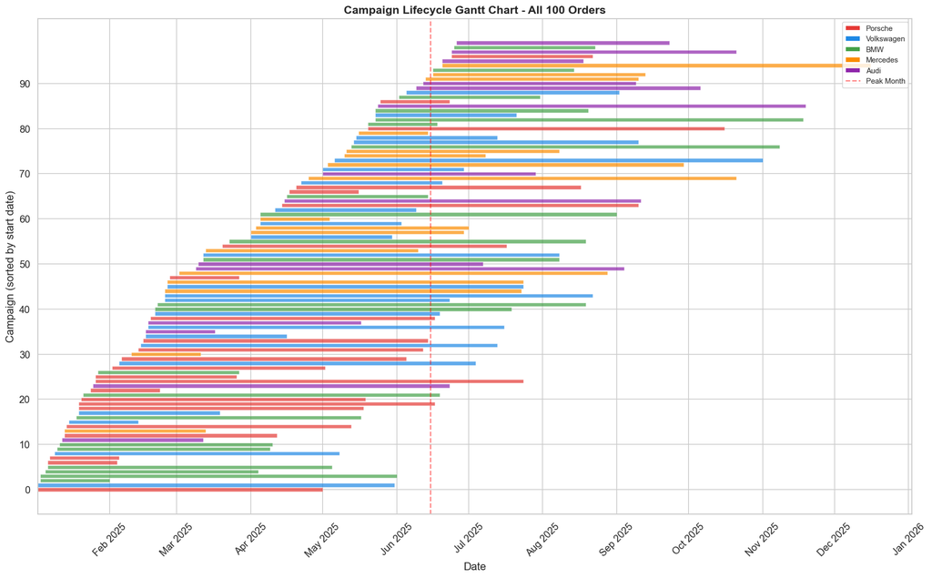

```python
# CHART 1: Campaign Lifecycle Gantt (replaces flat-line pacing chart)
fig, ax = plt.subplots(figsize=(16, 10))

gantt_data = df_order_stats.sort_values("DIM_START_DATE").reset_index(drop=True)
customer_colors = {"Porsche": "#E53935", "Volkswagen": "#1E88E5", "BMW": "#43A047",
                   "Mercedes": "#FB8C00", "Audi": "#8E24AA"}

for i, row in gantt_data.iterrows():
    color = customer_colors.get(row["DIM_CUSTOMER"], '#999999')
    ax.barh(i, (row["DIM_END_DATE"] - row["DIM_START_DATE"]).days, left=row["DIM_START_DATE"],
            color=color, alpha=0.7, height=0.8, edgecolor="white", linewidth=0.3)

ax.set_xlabel("Date")
ax.set_ylabel("Campaign (sorted by start date)")
ax.set_title("Campaign Lifecycle Gantt Chart - All 100 Orders", fontsize=14, fontweight="bold")
ax.xaxis.set_major_formatter(mdates.DateFormatter("%b %Y"))
ax.xaxis.set_major_locator(mdates.MonthLocator())
plt.xticks(rotation=45)

# Add vertical line for peak month
ax.axvline(x=pd.Timestamp("2025-06-15"), color="red", linestyle="--", alpha=0.5, label="Peak Budget (Jun)")

from matplotlib.patches import Patch
legend_elements = [Patch(facecolor=c, label=n) for n, c in customer_colors.items()]
legend_elements.append(plt.Line2D([0], [0], color="red", linestyle="--", alpha=0.5, label="Peak Month"))
ax.legend(handles=legend_elements, loc="upper right", fontsize=9)

ax.set_yticks(range(0, len(gantt_data), 10))
ax.set_yticklabels(range(0, len(gantt_data), 10))

plt.tight_layout()

plt.show()
```

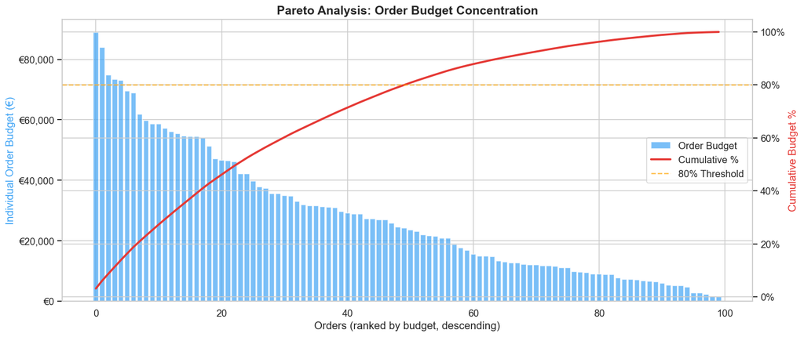

```python
# CHART 2: Pareto Curve
fig, ax1 = plt.subplots(figsize=(14, 6))

ax1.bar(range(len(df_sorted_orders)), df_sorted_orders["MSR_TOTAL_BUDGET"],
        color="#42A5F5", alpha=0.7, label="Order Budget")
ax1.set_xlabel("Orders (ranked by budget, descending)")
ax1.set_ylabel("Individual Order Budget (€)", color="#42A5F5")
ax1.yaxis.set_major_formatter(mticker.FuncFormatter(lambda x, p: f"€{x:,.0f}"))

ax2 = ax1.twinx()
ax2.plot(range(len(df_sorted_orders)), df_sorted_orders["%_CUMULATIVE_BUDGET"],
         color="#E53935", linewidth=2.5, label="Cumulative %")
ax2.set_ylabel("Cumulative Budget %", color="#E53935")
ax2.axhline(y=80, color="orange", linestyle='--', alpha=0.7, label="80% Threshold")
ax2.yaxis.set_major_formatter(mticker.FuncFormatter(lambda x, p: f'{x:.0f}%'))

lines1, labels1 = ax1.get_legend_handles_labels()
lines2, labels2 = ax2.get_legend_handles_labels()
ax1.legend(lines1 + lines2, labels1 + labels2, loc='center right')

plt.title("Pareto Analysis: Order Budget Concentration", fontsize=15, fontweight="bold")
plt.tight_layout()

plt.show()
```

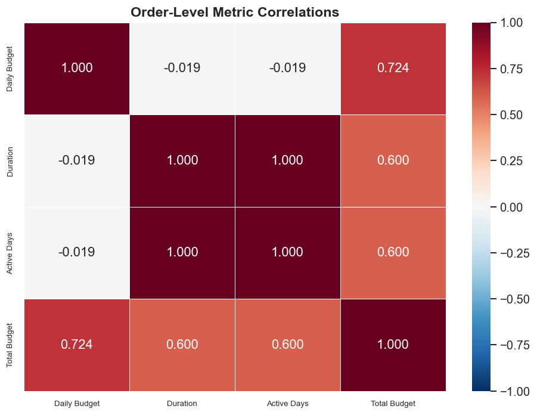

```python
corr_temp = corr_matrix.copy()
mapping = {
    "FCT_DAILY_BUDGET": "Daily Budget",
    "MSR_CAMPAIGN_DURATION": "Duration",
    "DIM_ACTIVE_DAYS": "Active Days",
    "MSR_TOTAL_BUDGET": "Total Budget"
}

# Rename both the top (columns) and the side (index)
corr_temp.rename(columns=mapping, index=mapping, inplace=True)
# CHART 3: Correlation Heatmap (order-level metrics)
fig, ax = plt.subplots(figsize=(8, 6))
sns.heatmap(corr_temp, annot=True, fmt=".3f", cmap="RdBu_r", center=0,
            linewidths=0.5, vmin=-1, vmax=1, ax=ax)
ax.set_title("Order-Level Metric Correlations", fontsize=14, fontweight="bold")
ax.tick_params(axis="both", which="major", labelsize=8)
plt.tight_layout()

plt.show()
```

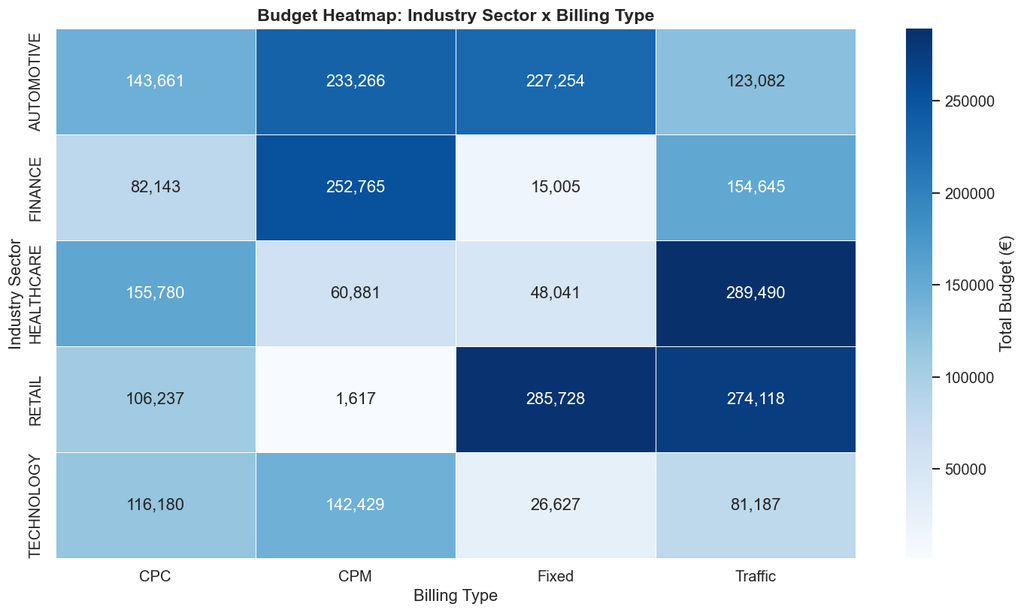

```python
# CHART 4: Heatmap - Industry x Billing Type
ind_billing = df.pivot_table(values="FCT_DAILY_BUDGET", index="DIM_INDUSTRY_SECTOR_CODE",
                             columns="DIM_BILLING_TYPE", aggfunc="sum", fill_value=0)

fig, ax = plt.subplots(figsize=(12, 7))
sns.heatmap(ind_billing, annot=True, fmt=",.0f", cmap="Blues", linewidths=0.5,
            cbar_kws={"label": "Total Budget (€)"}, ax=ax)
ax.set_title("Budget Heatmap: Industry Sector x Billing Type", fontsize=14, fontweight="bold")
ax.set_ylabel("Industry Sector")
ax.set_xlabel("Billing Type")

plt.tight_layout()

plt.show()
```

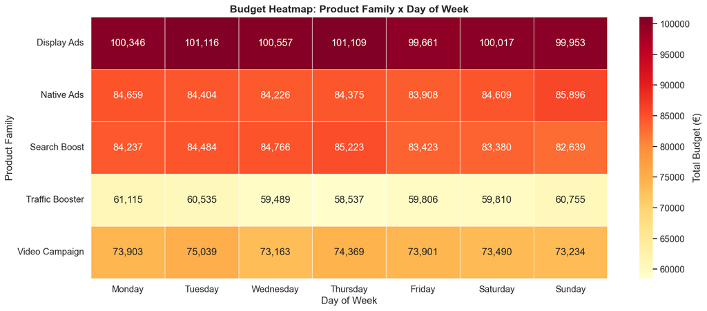

```python
# CHART 5: Heatmap - Day of Week x Product Family
dow_product = df.pivot_table(values="FCT_DAILY_BUDGET", index="DIM_PRODUCT_FAMILY",
                             columns="DIM_WEEKDAY", aggfunc="sum")
dow_order = ["Monday", "Tuesday", "Wednesday", "Thursday", "Friday", "Saturday", "Sunday"]
dow_product = dow_product.reindex(columns=dow_order)

fig, ax = plt.subplots(figsize=(14, 6))
sns.heatmap(dow_product, annot=True, fmt=",.0f", cmap="YlOrRd", linewidths=0.5,
            cbar_kws={"label": "Total Budget (€)"}, ax=ax)
ax.set_title("Budget Heatmap: Product Family x Day of Week", fontsize=14, fontweight="bold")
ax.set_ylabel("Product Family")
ax.set_xlabel("Day of Week")

plt.tight_layout()

plt.show()
```

[figure not shown]

```python
# CHART 6: Device Mix & Revenue Type
fig, axes = plt.subplots(1, 2, figsize=(16, 6))

device_budget = df.groupby("DIM_DEVICE")["FCT_DAILY_BUDGET"].sum().sort_values(ascending=False)
device_budget.plot(kind="bar", ax=axes[0], color=sns.color_palette("viridis", len(device_budget)), edgecolor="white")
axes[0].set_title("Budget by Device Type", fontweight="bold")
axes[0].set_ylabel("Total Budget (€)")
axes[0].yaxis.set_major_formatter(mticker.FuncFormatter(lambda x, p: f'${x:,.0f}'))
axes[0].tick_params(axis="x", rotation=45)

rev_budget = df.groupby("DIM_REVENUE_TYPE")["FCT_DAILY_BUDGET"].sum().sort_values(ascending=False)
rev_budget.plot(kind="bar", ax=axes[1], color=sns.color_palette("magma", len(rev_budget)), edgecolor="white")
axes[1].set_title("Budget by Revenue Type", fontweight="bold")
axes[1].set_ylabel("Total Budget (€)")
axes[1].yaxis.set_major_formatter(mticker.FuncFormatter(lambda x, p: f"€{x:,.0f}"))
axes[1].tick_params(axis="x", rotation=45)

plt.tight_layout()

plt.show()
```